# Predict bulk from pseudobulk: SCPCP000001

Stephanie J. Spielman

2025-02-05

*Introduction coming later.*

## Setup

```r
renv::load()

library(ggplot2)
theme_set(theme_bw())
```

```r
project_id <- "SCPCP000001"

# As identified in https://github.com/AlexsLemonade/scpca-paper-figures/issues/135
exclude_samples <- c("SCPCS000003")
```

### Paths

```r
analysis_dir <- here::here("analysis", "pseudobulk-bulk-prediction")
data_dir <- file.path(analysis_dir, "data")
metadata_dir <- file.path(rprojroot::find_root(rprojroot::is_renv_project), "s3_files")

sample_metadata_file <- file.path(metadata_dir, "scpca-sample-metadata.tsv")
library_metadata_file <- file.path(metadata_dir, "scpca-library-metadata.tsv")


bulk_counts_file <- file.path(data_dir, "scpca_data", "normalized_bulk_counts.rds")
pseudobulk_file <- file.path(data_dir, "pseudobulk", glue::glue("{project_id}-pseudobulk.tsv"))
```

We’ll also source helper functions:

- `prepare_data()`: Read and prepare data frame of bulk and pseudobulk counts

```r
source(file.path(analysis_dir, "model-notebooks", "utils.R"))
```

### Read and prepare input data

```r
expr_df <- prepare_data(
  bulk_counts_file,
  pseudobulk_file,
  project_id,
  exclude_samples
)
```

## Models

First, we’ll fit three flavors of model for `bulk ~ pseudobulk`

- `fit_plain`: simple regression with no other effects
- `fit_additive`: add a `sample_id` additive effect
- `fit_interaction`: add a `sample_id` interaction effect

We’ll have a look at model fits to determine which to proceed with.

```r
models <- list(
  fit_plain = lm(bulk ~ pseudobulk, data = expr_df),
  fit_additive = lm(bulk ~ pseudobulk + sample_id, data = expr_df),
  fit_interaction = lm(bulk ~ pseudobulk * sample_id, data = expr_df)
)

purrr::map(models, summary)
```

```
$fit_plain

Call:
lm(formula = bulk ~ pseudobulk, data = expr_df)

Residuals:
     Min       1Q   Median       3Q      Max
-15.9389  -0.8387  -0.4183   1.3520  15.5255

Coefficients:
             Estimate Std. Error t value Pr(>|t|)
(Intercept) 0.4182719  0.0026269   159.2   <2e-16 ***
pseudobulk  1.0424789  0.0006278  1660.5   <2e-16 ***
---
Signif. codes:  0 '***' 0.001 '**' 0.01 '*' 0.05 '.' 0.1 ' ' 1

Residual standard error: 2.332 on 1024639 degrees of freedom
  (782 observations deleted due to missingness)
Multiple R-squared:  0.7291,    Adjusted R-squared:  0.7291
F-statistic: 2.757e+06 on 1 and 1024639 DF,  p-value: < 2.2e-16


$fit_additive

Call:
lm(formula = bulk ~ pseudobulk + sample_id, data = expr_df)

Residuals:
     Min       1Q   Median       3Q      Max
-15.9530  -0.8394  -0.3722   1.3517  15.5783

Coefficients:
                      Estimate Std. Error  t value Pr(>|t|)
(Intercept)          0.3637419  0.0095827   37.958  < 2e-16 ***
pseudobulk           1.0425788  0.0006277 1660.883  < 2e-16 ***
sample_idSCPCS000002 0.0347908  0.0134310    2.590 0.009588 **
sample_idSCPCS000004 0.0671410  0.0134309    4.999 5.76e-07 ***
sample_idSCPCS000005 0.0663712  0.0134309    4.942 7.75e-07 ***
sample_idSCPCS000007 0.0463473  0.0134311    3.451 0.000559 ***
sample_idSCPCS000008 0.0471718  0.0134310    3.512 0.000445 ***
```

[output cut: 57 more lines]

```
pseudobulk:sample_idSCPCS000014  1.447e-03  3.661e-03   0.395  0.69278
pseudobulk:sample_idSCPCS000015 -3.645e-03  3.646e-03  -1.000  0.31736
pseudobulk:sample_idSCPCS000016 -2.658e-03  3.642e-03  -0.730  0.46542
pseudobulk:sample_idSCPCS000017  1.101e-02  3.651e-03   3.014  0.00258 **
pseudobulk:sample_idSCPCS000019  1.907e-02  3.645e-03   5.231 1.69e-07 ***
pseudobulk:sample_idSCPCS000020 -5.111e-03  3.647e-03  -1.401  0.16108
pseudobulk:sample_idSCPCS000021 -2.897e-02  3.629e-03  -7.983 1.43e-15 ***
pseudobulk:sample_idSCPCS000022 -6.561e-03  3.657e-03  -1.794  0.07283 .
---
Signif. codes:  0 '***' 0.001 '**' 0.01 '*' 0.05 '.' 0.1 ' ' 1

Residual standard error: 2.331 on 1024607 degrees of freedom
  (782 observations deleted due to missingness)
Multiple R-squared:  0.7293,    Adjusted R-squared:  0.7293
F-statistic: 8.366e+04 on 33 and 1024607 DF,  p-value: < 2.2e-16
```

In the end, we have:

| model | $R^2$ | $\sigma$ |
| --- | --- | --- |
| `fit_plain` | $0.7291$ | $2.332$ |
| `fit_additive` | $0.7292$ | $2.332$ |
| `fit_interaction` | $0.7293$ | $2.331$ |

As such, these models have essentially the same predictive power and average error, implying either that controlling for sample may be capturing noise in this project or the statistically significant coefficients have minimal effect sizes. Most of the additive model coefficients are significant and range between `[0.03, 0.1]`, although two samples are a bit higher. In the the interaction model, over half the interaction effects are not significant, so this model may be capturing noise.

Let’s have a look at some residuals; I expect these will look about the same too, but let’s confirm.

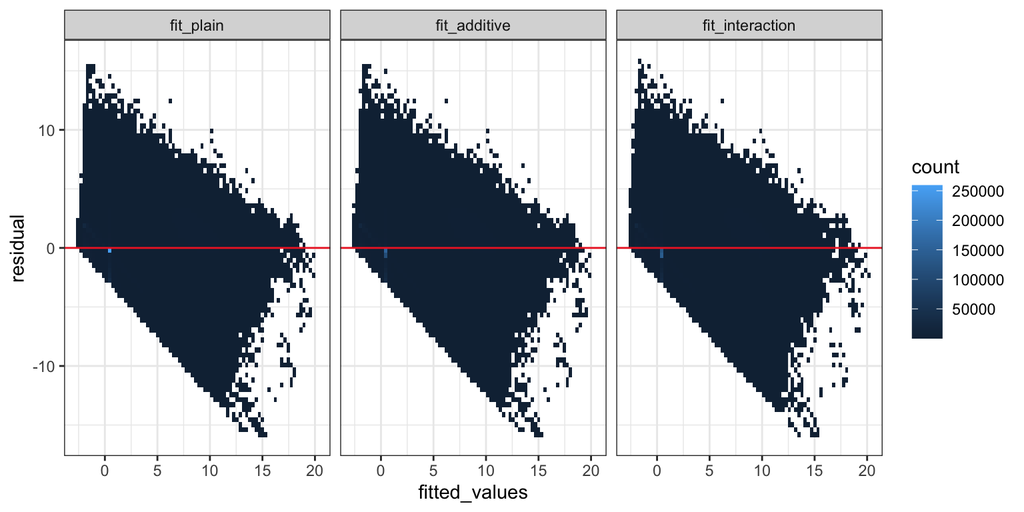

```r
residual_df <- models |>
  purrr::map(
    \(fit) {
      res_df <- data.frame(
        residual = unname(residuals(fit)),
        fitted_values = unname(fitted(fit))
      )
  }) |>
  purrr::list_rbind(names_to = "model_name") |>
  dplyr::mutate(
    model_name = forcats::fct_relevel(model_name, "fit_plain", "fit_additive", "fit_interaction")
  )

ggplot(residual_df) +
  aes(x = fitted_values, y = residual) +
  geom_bin_2d(bins = 75) +
  geom_hline(yintercept = 0, color = "firebrick2") +
  facet_wrap(vars(model_name), nrow = 1)
```

Based on this initial exploration, we’ll proceed with the additive model.

```r
fit <- models$fit_additive
rm(models)
```